# 2. Single Variant Association Tests

Single variant association tests are used to identify genetic variants associated with a phenotype of interest. Performing single-variant tests genome-wide is commonly referred to as a Genome Wide Association Study (GWAS). This tutorial demonstrates how to perform single variant association tests using regression models with the [GENESIS](https://bioconductor.org/packages/release/bioc/html/GENESIS.html) R/Bioconductor package.

## Prepare the Data

Before we can begin our association testing procedure, we must prepare our data in the required format. GENESIS requires that phenotype data be provided as an `AnnotatedDataFrame`, which is a special data structure provided by the [Biobase](https://www.bioconductor.org/packages/release/bioc/html/Biobase.html) R/Bioconductor package that contains both data and metadata. You should include a description of each variable in the metadata.

```r
library(Biobase)
```

#### Subject Phenotype Data

First, we load our subject phenotype data (i.e. both the outcome and covariate data), which is currently stored in a tab separated .tsv file. We then create metadata to describe the columns of the phenotype data. Finally, we create an `AnnotatedDataFrame` by pairing the phenotype data with the metadata.

```r
repo_path <- "https://github.com/UW-GAC/SISG_2022/raw/main"
if (!dir.exists("data")) dir.create("data")

# load phenotype data
phenfile <- "data/pheno_data.tsv"
if (!file.exists(phenfile)) download.file(file.path(repo_path, phenfile), phenfile)
phen <- read.table(phenfile, header = TRUE, sep = "\t", as.is = TRUE)
head(phen)
```

```
##   subject.id pop super_pop   study sex age  height status
## 1    HG00096 GBR       EUR study_1   M  47 165.300      0
## 2    HG00097 GBR       EUR study_3   F  47 144.780      1
## 3    HG00099 GBR       EUR study_2   F  40 185.500      0
## 4    HG00100 GBR       EUR study_3   F  45 150.622      1
## 5    HG00101 GBR       EUR study_3   M  40 177.800      0
## 6    HG00102 GBR       EUR study_1   F  49 169.100      0
```

```r
# create metadata
metadata <- data.frame(labelDescription = c("subject identifier",
                                            "population",
                                            "super population",
                                            "study identifier",
                                            "sex",
                                            "age at measurement",
                                            "height in cm",
                                            "outcome status 0/1"),
                       row.names = colnames(phen))
metadata
```

```
##              labelDescription
## subject.id subject identifier
## pop                population
## super_pop    super population
## study        study identifier
## sex                       sex
## age        age at measurement
## height           height in cm
## status     outcome status 0/1
```

```r
# create the AnnotatedDataFrame
annot <- AnnotatedDataFrame(phen, metadata)
annot
```

```
## An object of class 'AnnotatedDataFrame'
##   rowNames: 1 2 ... 1126 (1126 total)
##   varLabels: subject.id pop ... status (8 total)
##   varMetadata: labelDescription
```

We use the `pData` and `varMetaData` functions to access the data and metadata in our `AnnotatedDataFrame`, respectively.

```r
# access the data with the pData() function.
head(pData(annot))
```

```
##   subject.id pop super_pop   study sex age  height status
## 1    HG00096 GBR       EUR study_1   M  47 165.300      0
## 2    HG00097 GBR       EUR study_3   F  47 144.780      1
## 3    HG00099 GBR       EUR study_2   F  40 185.500      0
## 4    HG00100 GBR       EUR study_3   F  45 150.622      1
## 5    HG00101 GBR       EUR study_3   M  40 177.800      0
## 6    HG00102 GBR       EUR study_1   F  49 169.100      0
```

```r
# access the metadata with the varMetadata() function.
varMetadata(annot)
```

```
##              labelDescription
## subject.id subject identifier
## pop                population
## super_pop    super population
## study        study identifier
## sex                       sex
## age        age at measurement
## height           height in cm
## status     outcome status 0/1
```

#### Sample Identifiers

The GENESIS code to fit the regression model and perform the association tests also requires that the `AnnotatedDataFrame` have a column named `sample.id`, which represents a sample (i.e. sequencing instance) identifier. The values in the `sample.id` column must match the `sample.id` values in the GDS file(s) containing the sequencing data.

When designing a study, we generally advise using separate IDs for samples (sequencing instances) and subjects (individuals) and maintaining a sample to subject mapping file. This practice can be beneficial for quality control purposes; for example, when sample swaps are detected, the mapping between sequencing (indexed by `sample.id`) and phenotype (indexed by `subject.id`) data can easily be updated, rather than needing to modify and re-write phenotype data or sequencing metrics files.

```r
# load the sample subject mapping
mapfile <- "data/sample_subject_map.tsv"
if (!file.exists(mapfile)) download.file(file.path(repo_path, mapfile), mapfile)
map <- read.table(mapfile, header = TRUE, sep = "\t", as.is = TRUE)
head(map)
```

```
##   sample.id subject.id
## 1   HG00096    HG00096
## 2   HG00097    HG00097
## 3   HG00099    HG00099
## 4   HG00100    HG00100
## 5   HG00101    HG00101
## 6   HG00102    HG00102
```

Notice that, in this example, the 1000 Genomes sample identifiers are the same as the subject identifiers (which goes against our recommendation, but is OK for these exercises). We merge the `sample.id` information into our `AnnotatedDataFrame` with the phenotype data.

```r
# merge the sample-subject map with the phenotype data
dat <- merge(map, pData(annot), by = 'subject.id')
head(dat)
```

```
##   subject.id sample.id pop super_pop   study sex age  height status
## 1    HG00096   HG00096 GBR       EUR study_1   M  47 165.300      0
## 2    HG00097   HG00097 GBR       EUR study_3   F  47 144.780      1
## 3    HG00099   HG00099 GBR       EUR study_2   F  40 185.500      0
## 4    HG00100   HG00100 GBR       EUR study_3   F  45 150.622      1
## 5    HG00101   HG00101 GBR       EUR study_3   M  40 177.800      0
## 6    HG00102   HG00102 GBR       EUR study_1   F  49 169.100      0
```

```r
# add an item for `sample.id` to the metadata
meta <- rbind(sample.id = 'sample identifier',
              varMetadata(annot))
meta
```

```
##              labelDescription
## sample.id   sample identifier
## subject.id subject identifier
## pop                population
## super_pop    super population
## study        study identifier
## sex                       sex
## age        age at measurement
## height           height in cm
## status     outcome status 0/1
```

```r
# create a new AnnotatedDataFrame
annot <- AnnotatedDataFrame(dat, meta)
annot
```

```
## An object of class 'AnnotatedDataFrame'
##   rowNames: 1 2 ... 1126 (1126 total)
##   varLabels: subject.id sample.id ... status (9 total)
##   varMetadata: labelDescription
```

Save the `AnnotatedDataFrame` for future use.

```r
save(annot, file = "data/sample_phenotype_annotation.RData")
```

## Null Model

Now that our data is prepared, we can move on to the association testing procedure. The first step is to fit the “null model” – i.e., a model fit under the null hypothesis of no individual variant association. Operationally, this is fitting a regression model with the desired outcome phenotype and fixed effect covariates.

#### Fit the Null Model

We use the `fitNullModel` function from GENESIS. We need to specify the `AnnotatedDataFrame` with the phenotype data, the outcome variable (height), and the fixed effect covariates (sex, age, and study). If the sample set involves multiple distinct groups with different variances for the phenotype, we recommend allowing for heterogeneous residual variance among groups with the `group.var` parameter. If you take a closer look at the data, you will see that the variance of height differs by study.

```r
library(GENESIS)

# fit the null model
nullmod <- fitNullModel(annot,
                        outcome="height",
                        covars=c("sex", "age", "study"),
                        group.var="study",
                        verbose=FALSE)
save(nullmod, file="data/null_model.RData")
```

The `fitNullModel` function returns a lot of information about the model that was fit. We examine some of that information below; to see all of the components, try `names(nullmod)`.

```r
# description of the model we fit
nullmod$model
```

```
## $hetResid
## [1] TRUE
##
## $family
##
## Family: gaussian
## Link function: identity
##
##
## $outcome
## [1] "height"
##
## $covars
## [1] "sex"   "age"   "study"
##
## $formula
## [1] "height ~ sex + age + study + var(study)"
```

```r
# fixed effect regression estimates
nullmod$fixef
```

```
##                       Est         SE        Stat         pval
## (Intercept)  163.67175933 3.18936046 2633.542247 0.000000e+00
## sexM           6.28764509 0.68812251   83.491932 6.397653e-20
## age            0.07519782 0.06921691    1.180283 2.772984e-01
## studystudy_2  10.63152325 0.82176939  167.375182 2.769992e-38
## studystudy_3  -8.96183691 0.84479021  112.537257 2.724959e-26
```

```r
# residual variance estimates by group.var
nullmod$varComp
```

```
## V_study_1 V_study_3 V_study_2
##  98.20191 168.82044 155.70722
```

```r
# model fit: fitted values, residuals
head(nullmod$fit)
```

```
##         outcome workingY fitted.values resid.marginal    resid.PY
## HG00096 165.300  165.300      173.4937      -8.193702 -0.08343729
## HG00097 144.780  144.780      158.2442     -13.464220 -0.07975468
## HG00099 185.500  185.500      177.3112       8.188805  0.05259104
## HG00100 150.622  150.622      158.0938      -7.471824 -0.04425900
## HG00101 177.800  177.800      164.0055      13.794520  0.08171119
## HG00102 169.100  169.100      167.3565       1.743547  0.01775472
##         resid.cholesky sample.id
## HG00096     -0.8268376   HG00096
## HG00097     -1.0362599   HG00097
## HG00099      0.6562452   HG00099
## HG00100     -0.5750613   HG00100
## HG00101      1.0616810   HG00101
## HG00102      0.1759437   HG00102
```

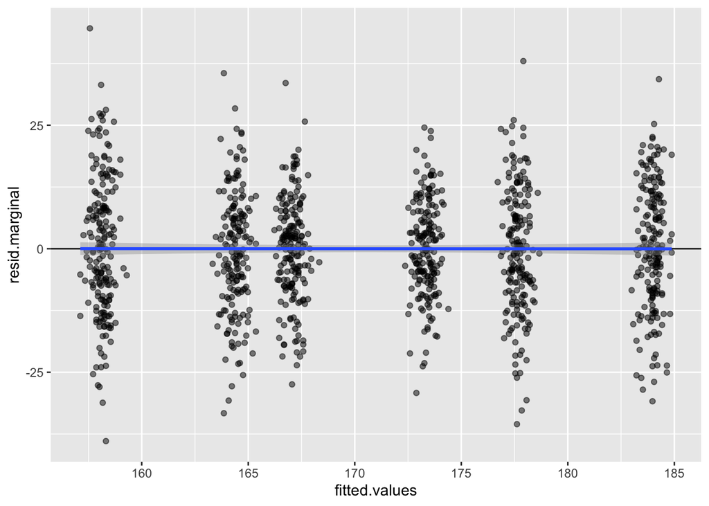

```r
# plot the residuals vs the fitted values
library(ggplot2)
ggplot(nullmod$fit, aes(x = fitted.values, y = resid.marginal)) +
    geom_point(alpha = 0.5) +
    geom_hline(yintercept = 0) +
    geom_smooth(method = 'lm')
```

### Exercise 2.1 (Data Studio)

As discussed in the lecture, we recommend a fully adjusted two-stage inverse Normalization procedure for fitting the null model when phenotypes have non-Normal distributions. Using the `two.stage` option in `fitNullModel`, fit a two-stage null model. Compare these residuals with the residuals from the original null model.

```r
# your solution here
#
#
#
#
#
#
#
#
#
```

### Solution 2.1 (Data Studio)

As discussed in the lecture, we recommend a fully adjusted two-stage inverse Normalization procedure for fitting the null model when phenotypes have non-Normal distributions. Using the `two.stage` option in `fitNullModel`, fit a two-stage null model. Compare these residuals with the residuals from the original null model.

To run the fully adjusted two.stage null model, we simply set the `two.stage` option to `TRUE`. The `norm.option` parameter determines if the inverse Normalization should be done with all samples together (`"all"`) or within each `group.var` group separately (`"by.group"`).

```r
nullmod.twostage <- fitNullModel(annot,
                                 outcome="height",
                                 covars=c("sex", "age", "study"),
                                 group.var="study",
                                 two.stage = TRUE,
                                 norm.option = "all",
                                 verbose=FALSE)
save(nullmod.twostage, file="data/null_model_two_stage.RData")

# description of the model we fit
nullmod.twostage$model
```

```
## $hetResid
## [1] TRUE
##
## $family
##
## Family: gaussian
## Link function: identity
##
##
## $outcome
## [1] "height"
##
## $covars
## [1] "sex"   "age"   "study"
##
## $formula
## [1] "rankInvNorm(resid(height)) ~ sex + age + study + var(study)"
```

```r
# compare the marginal residuals

# merge the data for plotting
pdat <- merge(nullmod$fit, nullmod.twostage$fit,
              by = 'sample.id', suffixes = c('.orig', '.twostage'))
pdat <- merge(pdat, pData(annot), by = 'sample.id')
head(pdat, 2)
```

```
##   sample.id outcome.orig workingY.orig fitted.values.orig resid.marginal.orig
## 1   HG00096       165.30        165.30           173.4937           -8.193702
## 2   HG00097       144.78        144.78           158.2442          -13.464220
##   resid.PY.orig resid.cholesky.orig outcome.twostage workingY.twostage
## 1   -0.08343729          -0.8268376        -8.496836         -8.496836
## 2   -0.07975468          -1.0362599       -13.341857        -13.341857
##   fitted.values.twostage resid.marginal.twostage resid.PY.twostage
## 1             0.01380964               -8.510645       -0.08643190
## 2            -0.01425745              -13.327600       -0.07892831
##   resid.cholesky.twostage subject.id pop super_pop   study sex age height
## 1              -0.8576662    HG00096 GBR       EUR study_1   M  47 165.30
## 2              -1.0256339    HG00097 GBR       EUR study_3   F  47 144.78
##   status
## 1      0
## 2      1
```

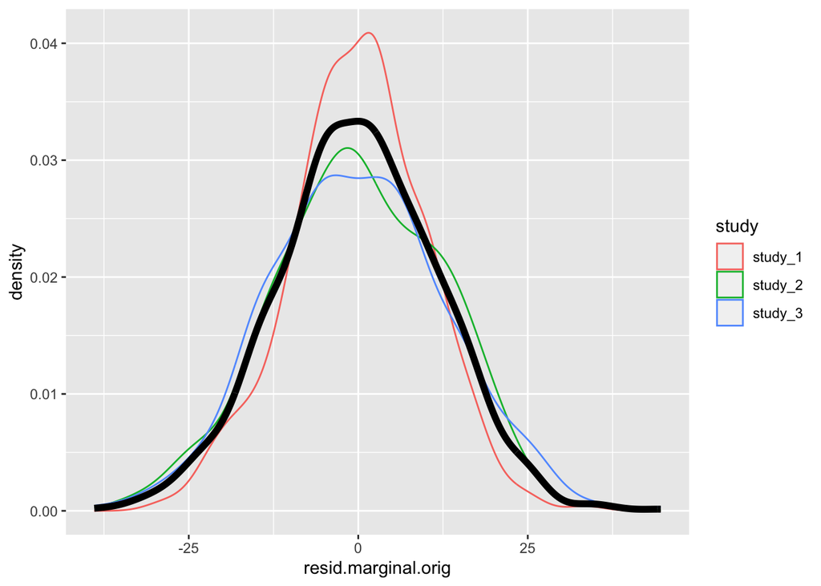

```r
# distribution of residuals - original null model
ggplot(pdat, aes(x = resid.marginal.orig)) +
    geom_density(aes(color = study)) +
    geom_density(size = 2)
```

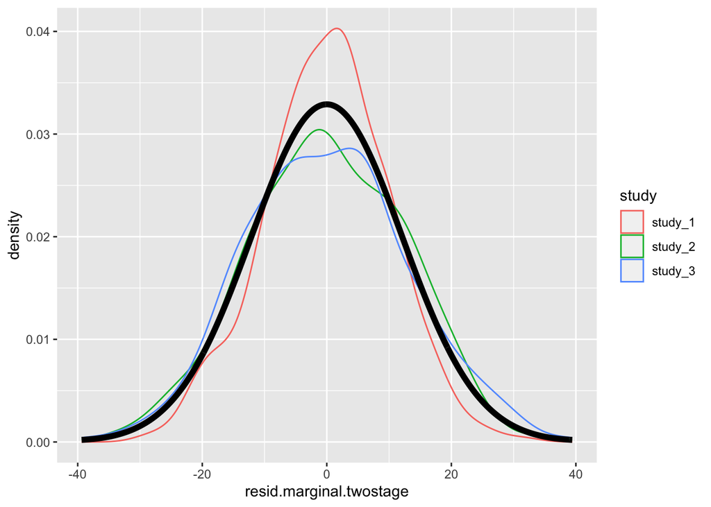

```r
# distribution of residuals - two stage null model
ggplot(pdat, aes(x = resid.marginal.twostage)) +
    geom_density(aes(color = study)) +
    geom_density(size = 2)
```

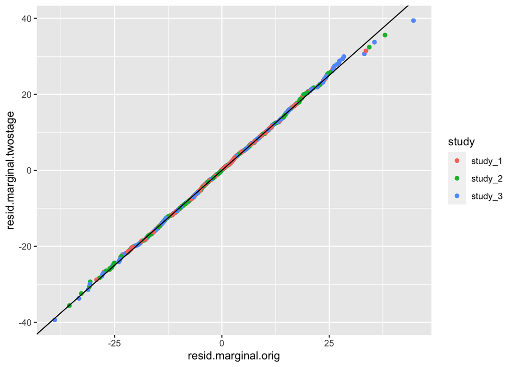

```r
# compare residuals
ggplot(pdat, aes(x = resid.marginal.orig, y = resid.marginal.twostage, color = study)) +
    geom_point() +
    geom_abline(intercept = 0, slope = 1)
```

There is not much difference in the residual here because the distribution of height is not far from Normal to begin. See [Sofer et al. (2019)](https://onlinelibrary.wiley.com/doi/10.1002/gepi.22188) for more information on the fully adjusted two-stage model.

$$\\[0.5in]$$

## Single-Variant Association Tests

After fitting the null model, we use score tests to test each variant across the genome separately for association with the outcome phenotype (i.e. height in our example). We use the `assocTestSingle` function from GENESIS.

#### Prepare the Iterator

First, we have to create a `SeqVarData` object linking the GDS file containing the sequencing data and the `AnnotatedDataFrame` containing the sample and phenotype data. We then create a `SeqVarBlockIterator` object, which breaks the set of all variants in the `SeqVarData` object into blocks, allowing us to analyze genome-wide in manageable pieces.

```r
library(SeqVarTools)

gdsfile <- "data/1KG_phase3_subset_chr1.gds"
if (!file.exists(gdsfile)) download.file(file.path(repo_path, gdsfile), gdsfile)
gdsfmt::showfile.gds(closeall=TRUE) # make sure file is not already open
gds <- seqOpen(gdsfile)

# make the seqVarData object
seqData <- SeqVarData(gds, sampleData=annot)

# make the iterator object
iterator <- SeqVarBlockIterator(seqData, verbose=FALSE)
iterator
```

```
## SeqVarBlockIterator object; on iteration 1 of 1
##  | GDS:
## File: /Users/mconomos/Documents/Teaching/SISG_2023/data/1KG_phase3_subset_chr1.gds (70.5K)
## +    [  ] *
## |--+ description   [  ] *
## |--+ sample.id   { Str8 1126 LZMA_ra(9.66%), 877B } *
## |--+ variant.id   { Int32 1120 LZMA_ra(17.5%), 793B } *
## |--+ position   { Int32 1120 LZMA_ra(78.5%), 3.4K } *
## |--+ chromosome   { Str8 1120 LZMA_ra(4.55%), 109B } *
## |--+ allele   { Str8 1120 LZMA_ra(26.0%), 1.2K } *
## |--+ genotype   [  ] *
## |  |--+ data   { Bit2 2x1126x1121 LZMA_ra(8.34%), 51.4K } *
## |  |--+ extra.index   { Int32 3x0 LZMA_ra, 18B } *
## |  \--+ extra   { Int16 0 LZMA_ra, 18B }
## |--+ phase   [  ]
## |  |--+ data   { Bit1 1126x1120 LZMA_ra(0.11%), 177B } *
## |  |--+ extra.index   { Int32 3x0 LZMA_ra, 18B } *
## |  \--+ extra   { Bit1 0 LZMA_ra, 18B }
## |--+ annotation   [  ]
## |  |--+ id   { Str8 1120 LZMA_ra(40.4%), 3.6K } *
## |  |--+ qual   { Float32 1120 LZMA_ra(2.46%), 117B } *
## |  |--+ filter   { Int32,factor 1120 LZMA_ra(2.46%), 117B } *
## |  |--+ info   [  ]
## |  \--+ format   [  ]
## \--+ sample.annotation   [  ]
##  | sampleData:
## An object of class 'AnnotatedDataFrame'
##   rowNames: 1 2 ... 1126 (1126 total)
##   varLabels: subject.id sample.id ... status (9 total)
##   varMetadata: labelDescription
##  | variantData:
## An object of class 'AnnotatedDataFrame': none
```

The `SeqVarBlockIterator` object looks a lot like the GDS objects we’ve seen before, but with an additional `sample.annotation` field that contains the phenotype data from the linked `AnnotatedDataFrame`.

#### Run the Association Tests

The `assocTestSingle` function takes the already fitted null model as input, performs score tests by iterating over all blocks of variants in the `SeqVarBlockIterator` object, and then concatenates and returns the results.

```r
# run the single-variant association test
assoc <- assocTestSingle(iterator,
                         null.model = nullmod)
```

```
## # of selected samples: 1,126
```

```r
dim(assoc)
```

```
## [1] 1129   14
```

```r
head(assoc)
```

```
##   variant.id chr     pos allele.index n.obs         freq MAC      Score
## 1          1   1  970546            1  1126 0.0039964476   9 -0.1191236
## 2          2   1  985900            1  1126 0.0492895204 111 -1.6707553
## 3          3   1 1025045            1  1126 0.0004440497   1 -0.2795838
## 4          4   1 1265550            1  1126 0.0008880995   2 -0.1105487
## 5          5   1 1472676            1  1126 0.0071047957  16  0.3630992
## 6          6   1 1735725            1  1126 0.0022202487   5 -0.1300405
##    Score.SE Score.Stat  Score.pval        Est   Est.SE          PVE
## 1 0.2577712 -0.4621292 0.643988693  -1.792788 3.879410 0.0001905115
## 2 0.8841849 -1.8895996 0.058811535  -2.137109 1.130985 0.0031851797
## 3 0.1007173 -2.7759261 0.005504472 -27.561563 9.928781 0.0068740102
## 4 0.1085480 -1.0184319 0.308472744  -9.382319 9.212515 0.0009252485
## 5 0.3456555  1.0504657 0.293504065   3.039054 2.893054 0.0009843694
## 6 0.1973175 -0.6590420 0.509868790  -3.340007 5.067973 0.0003874544
```

Each row of the results data.frame represents one tested variant and includes: variant information (`variant.id`, `chr`, and `pos`), the number of samples tested (`n.obs`), the minor allele count (`MAC`), the effect allele frequency (`freq`), the score value (`Score`) and its standard error (`Score.SE`), the score test statistic (`Score.Stat`) and $p$-value (`Score.pval`), and an approximation of the effect allele effect size (`Est`) and its standard error (`Est.SE`). When using a `SeqVarData` object, the effect allele is the alternate allele.

We make a QQ plot to examine the $p$-values:

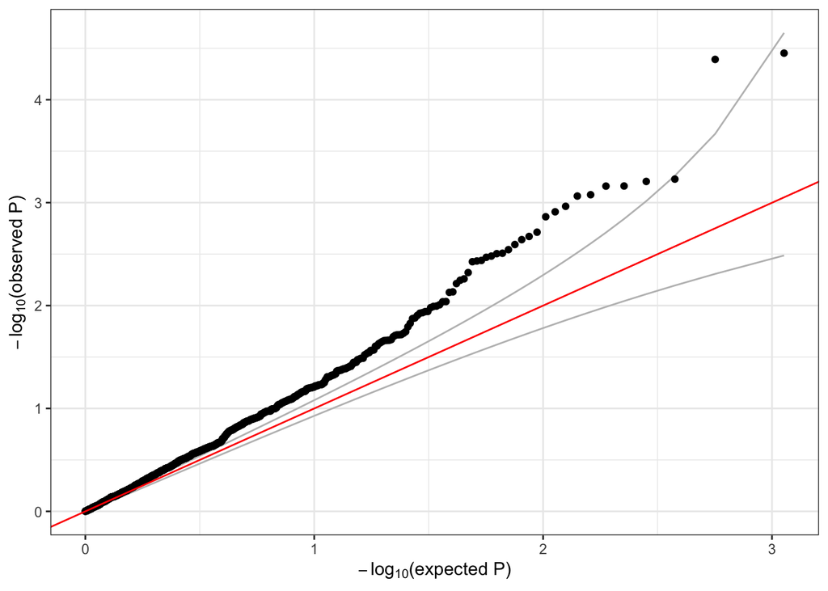

```r
library(ggplot2)
qqPlot <- function(pval) {
    pval <- pval[!is.na(pval)]
    n <- length(pval)
    x <- 1:n
    dat <- data.frame(obs=sort(pval),
                      exp=x/n,
                      upper=qbeta(0.025, x, rev(x)),
                      lower=qbeta(0.975, x, rev(x)))

    ggplot(dat, aes(-log10(exp), -log10(obs))) +
        geom_line(aes(-log10(exp), -log10(upper)), color="gray") +
        geom_line(aes(-log10(exp), -log10(lower)), color="gray") +
        geom_point() +
        geom_abline(intercept=0, slope=1, color="red") +
        xlab(expression(paste(-log[10], "(expected P)"))) +
        ylab(expression(paste(-log[10], "(observed P)"))) +
        theme_bw()
}

qqPlot(assoc$Score.pval)
```

A lot of the variants we tested are very rare – i.e., the alternate allele is not observed for many samples. Single-variant tests do not perform well for very rare variants (we discuss testing rare variants in more detail later). We can use the minor allele count (MAC) observed in the sample to filter rare variants that we may expect to have unreliable test results.

```r
summary(assoc$MAC)
```

```
##    Min. 1st Qu.  Median    Mean 3rd Qu.    Max.
##    1.00    1.00    3.00   86.62   30.00 1123.00
```

```r
sum(assoc$MAC < 5)
```

```
## [1] 619
```

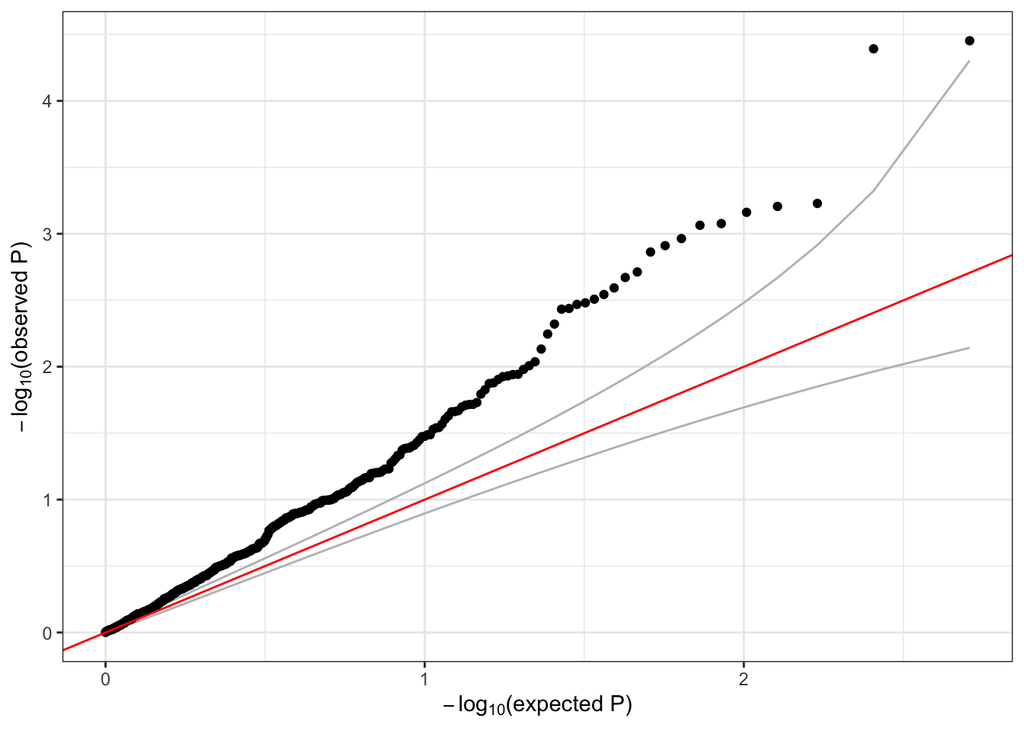

```r
qqPlot(assoc$Score.pval[assoc$MAC >= 5])
```

We should expect the majority of variants to fall near the red `y=x` line in the QQ plot. The deviation above the line, commonly referred to as “inflation” is indicative of some model issue. In this example, the issue is likely driven by the fact that we’ve ignored genetic ancestry and relatedness among these subjects – more to come later when we discuss mixed models.

### Exercise 2.2 (Data Studio)

GENESIS also supports testing binary (e.g. case/control) outcomes. We can fit a null model using logistic regression by specifying the argument `family=binomial` in the `fitNullModel` function. Use the `status` column in the sample annotation to fit a null model for simulated case/control status, with `sex` and `pop` as covariates. Run single-variant association tests using this model and make a QQ plot of all variants with MAC >= 5.

```r
# your solution here
#
#
#
#
#
#
#
#
#
```

### Solution 2.2 (Data Studio)

GENESIS also supports testing binary (e.g. case/control) outcomes. We can fit a null model using logistic regression by specifying the argument `family=binomial` in the `fitNullModel` function. Use the `status` column in the sample annotation to fit a null model for simulated case/control status, with `sex` and `pop` as covariates. Run single-variant association tests using this model and make a QQ plot of all variants with MAC >= 5.

When testing binary outcomes, we should fit our null model using logistic regression. To do so, we simply set the argument `family=binomial` in `fitNullModel`. Note that the parameter `group.var` is no longer relevant here, as the logistic model specifies the mean-variance relationship.

```r
# fit the null model with logistic regression
nullmod.status <- fitNullModel(annot,
                               outcome="status",
                               covars=c("sex", "pop"),
                               family=binomial,
                               verbose=FALSE)

# reset the iterator since we used it in the prior analysis
resetIterator(iterator, verbose=FALSE)

# run the single-variant association test
assoc.status <- assocTestSingle(iterator,
                                null.model = nullmod.status,
                                test="Score")
```

```
## # of selected samples: 1,126
```

```
## Using 6 CPU cores
```

```r
dim(assoc.status)
```

```
## [1] 1129   14
```

```r
head(assoc.status)
```

```
##   variant.id chr     pos allele.index n.obs         freq MAC       Score
## 1          1   1  970546            1  1126 0.0039964476   9  0.20256722
## 2          2   1  985900            1  1126 0.0492895204 111 -2.64169956
## 3          3   1 1025045            1  1126 0.0004440497   1 -0.09916904
## 4          4   1 1265550            1  1126 0.0008880995   2  0.81717324
## 5          5   1 1472676            1  1126 0.0071047957  16  0.64418361
## 6          6   1 1735725            1  1126 0.0022202487   5 -0.46319177
##    Score.SE Score.Stat Score.pval        Est    Est.SE          PVE
## 1 0.8351783  0.2425437 0.80835892  0.2904095 1.1973491 5.242118e-05
## 2 2.6522412 -0.9960254 0.31923781 -0.3755410 0.3770396 8.840314e-04
## 3 0.2972472 -0.3336248 0.73866267 -1.1223819 3.3642035 9.918446e-05
## 4 0.4033577  2.0259271 0.04277226  5.0226565 2.4791892 3.657417e-03
## 5 1.0778277  0.5976685 0.55006117  0.5545121 0.9277921 3.183080e-04
## 6 0.6396675 -0.7241134 0.46899613 -1.1320153 1.5633123 4.672400e-04
```

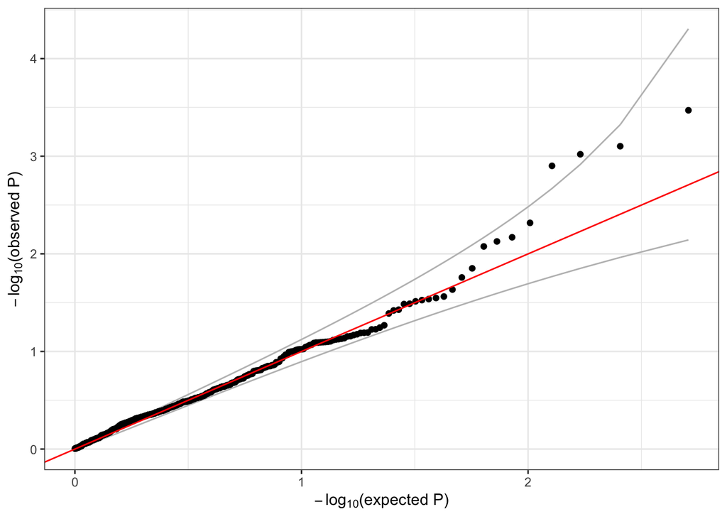

```r
# make a QQ plot
qqPlot(assoc.status$Score.pval[assoc.status$MAC >= 5])
```

Extra: in samples with highly imbalanced case:control ratios, the Score test can perform poorly for low frequency variants. Saddlepoint approximation (SPA) can be used to improve p-value calculations, and is available in GENESIS by setting the argument `test=Score.SPA` in `assocTestSingle`. See Dey et al. (2017) and [Zhou et al. (2018)](https://www.nature.com/articles/s41588-018-0184-y) for details on using SPA in GWAS.

```r
# close the GDS file!
seqClose(seqData)
```